# Data Transformations: Linear Models

We’re going to look at a non-linear exponential relationship of the form $y = ae^{bx}$. We can find a linear way of writing this equation by taking the $ln$ of both sides:

$$ln(y) = ln(ae^{bx})$$
Due to log rules,

$$ln(y) = ln(a) + ln(e^{bx})$$
$$ln(y) = ln(a) + bx$$

We can rearrange the terms to look like the linear equation $y = mx + b$:

$$\underbrace{ln(y)}_\text{y} = \underbrace{bx}_\text{mx} + \underbrace{ln(a)}_\text{b}$$

Therefore, you should see a linear relationship when plotting $ln(y)$ and x. Let’s look at this with a small data set in R. We’ll plot the original data and the log transformed data side-by-side.

*Note: in R, log(x) is the natural log by default. To use log with another base, you must specify the base argument (log(x, base = 10)).*

```r
# Enter x values.
x <- c(0, 2, 4, 6)
# Enter y values.
y <- c(1, 0.37, 0.14, 0.05)
#### Plot x and y relationship.
# Split screen to show before and after transformation side by side.
par(mfrow = c(1, 2))
# Plot the line first. With few data points, the relationship is a
# bit hard to see.
plot(x, y, type = 'l', lty = 2, col = 'grey', main = "Data")
# Add points on top of line.
points(x, y, pch = 16)
```

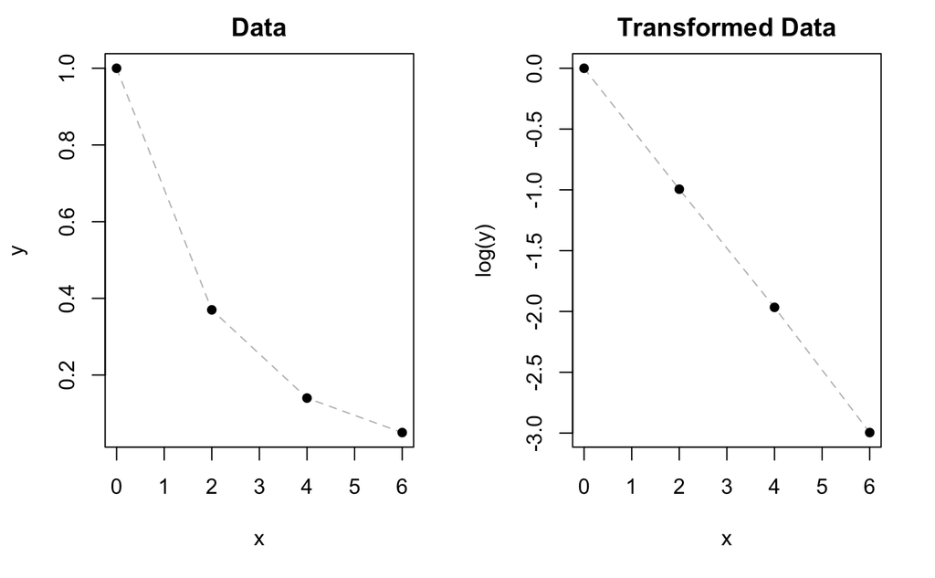

```r
# Plot x with log-transformed y values.
plot(x, log(y), type = 'l', lty = 2, col = 'grey', main = "Transformed Data")
points(x, log(y), pch = 16)
```

We can now fit a linear model to the transformed data in the same way we would for linear data.

```r
# Fit linear model.
fit <- lm(log(y) ~ x)
# Print summary of fit to investigate coefficients of linear model.
summary(fit)
```

```
Call:
lm(formula = log(y) ~ x)

Residuals:
        1         2         3         4
-0.004834 -0.003181  0.020864 -0.012849

Coefficients:
             Estimate Std. Error  t value Pr(>|t|)
(Intercept)  0.004834   0.014895    0.325    0.776
x           -0.497953   0.003981 -125.084 6.39e-05 ***
---
Signif. codes:  0 ‘***’ 0.001 ‘**’ 0.01 ‘*’ 0.05 ‘.’ 0.1 ‘ ’ 1

Residual standard error: 0.0178 on 2 degrees of freedom
Multiple R-squared:  0.9999,    Adjusted R-squared:  0.9998
F-statistic: 1.565e+04 on 1 and 2 DF,  p-value: 6.391e-05
```

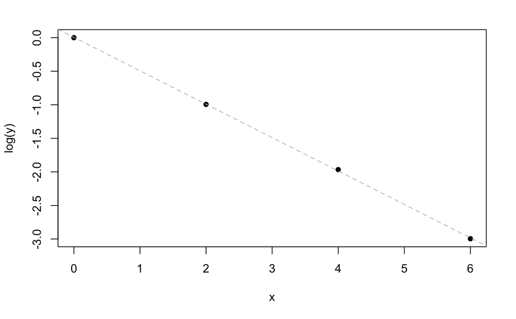

```r
# Let's plot the line of best fit.
plot(x, log(y), pch = 16)
abline(fit, lty = 2, col = 'grey')
```

We can see from the summary that our coefficient for the intercept is 0.0048343 and the slope is -0.4979529. We now want to take these coefficients and convert our linear equation back into our exponential equation.

$$\underbrace{ln(y)}_\text{y} = \underbrace{bx}_\text{mx} + \underbrace{ln(a)}_\text{b}$$

In this case, our slope is equivalent to the variable $b$ in our exponential equation. However, in our linear version of the exponential equation, the intercept is equivalent to $ln(a)$. Therefore, to find our $a$ variable, we must solve for $ln(a) =$ 0.0048343.

```r
exp(fit$coefficients[1])
```

```
(Intercept)
   1.004846
```

Rounding $a$ to 1 and $b$ to -0.5, we get $y = 1e^{-0.5x} \rightarrow y = e^{-0.5x}$. Let’s plot this line on top of our original data.

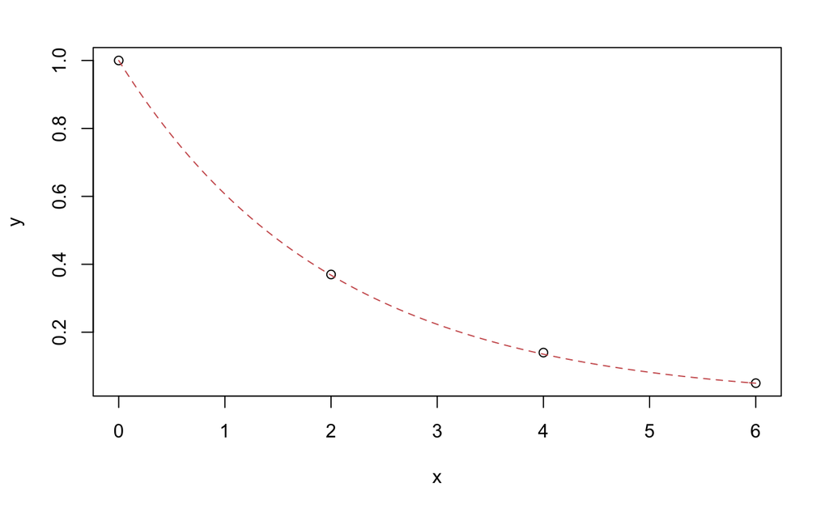

```r
# Plot non-transformed data.
plot(x, y)
curve(exp(-0.5*x), add = T, lty = 2, col = "#CD5C5C")
```

Ooh la la! Look at that curve!